# GHV Ch. 20 Figures

# Figure 20.1

Distributions for health outcomes, not IHDP data.

# Figure 20.2

Distributions for health outcomes, not IHDP data.

# Figure 20.3

Treatment effect with confidence bars plot from Electric Company example.

```r
for (k in 1:4) {
    fit_supp <- stan_glm(post_test ~ supp + pre_test, data = electric, subset = (grade ==
        k) & (!is.na(supp)))
}
```

# Figure 20.4

Same as Figure 10.1 from GH. Two plots showing imbalance, but not any specific covariate, just arbitrary RV x.

# Figure 20.5

Same as Figure 10.2 from GH. Three plots showing one and two examples of no and partial overlap, respectively. Also not of any specific covariate, just an arbitrary RV.

# Figure 20.6

Two plots showing hypothetical post-/pre- test scores and the difference between estimated regression lines and true regression surface.

# Figure 20.7

Same plot as 20.6, with an additional plot with regressions fit only to the part of the covariate space with overlap.

# Figure 20.8

Four plots from Electric Company example showing post-/pre- test scores; each plot represents a separate regression fit for each grade.

# Figure 20.9

Balance plot with following covariates:

Child:

- neg.bw
- preterm
- dayskidh
- sex
- first
- age

Mother:

- black
- hispanic
- white
- b.marr
- lths
- hs
- ltcoll
- college
- work.dur
- prenatal
- momage

```r
covs.all <- setdiff(names(cc2), c("row.names", "row.names.1", "treat", "treat0",
    "ppvtr.36"))
covs <- c("neg.bw", "preterm", "dayskidh", "sex", "first", "age", "black", "hispanic",
    "white", "b.marr", "lths", "hs", "ltcoll", "college", "work.dur", "prenatal",
    "momage")
form_20.9 <- as.formula(cc2[, c("treat", covs)])
ps_fit_20.9 <- stan_glm(form_20.9, family = binomial(link = "logit"), data = cc2,
    algorithm = "optimizing")
pscores_20.9 <- apply(posterior_linpred(ps_fit_20.9, type = "link"), 2, mean)
matches_20.9 <- matching(z = cc2$treat, score = pscores_20.9, replace = FALSE)
bal_20.9 <- balance(rawdata = cc2[, covs.all], cc2$treat, matched = matches_20.9$cnts,
    estimand = "ATT")
```

```
## Balance diagnostics assume that the estimand is the ATT
```

```r
par(mfrow = c(2, 1))
plot.balance(bal_20.9, which.covs = "cont")
```

[output not shown]

```
## $raw
##     neg.bw     state3     state2      state      educ3       educ
## 4.68266037 0.88068841 1.13296389 1.29288050 0.14454234 0.08550107
##     ethnic      ptcat   bs.by.aa   b.8state   unemp.rt     ineeds
## 0.03225337 3.39693386 0.53741780 1.09200241 0.04822287 0.28859124
##     income    b.state   dayskidh        age    preterm         bw
## 0.34563643 2.88161190 0.93213392 0.16211703 2.54588810 4.68266037
##      momed    momrace     momage
## 0.08550107 0.33730446 0.11772830
##
## $matched
##     neg.bw     state3     state2      state      educ3       educ
## 0.82329235 0.87186205 1.14851383 1.31047947 0.06150429 0.09327597
##     ethnic      ptcat   bs.by.aa   b.8state   unemp.rt     ineeds
## 0.06529413 0.84727435 0.77639433 1.11865462 0.07043075 0.21267937
##     income    b.state   dayskidh        age    preterm         bw
## 0.40678992 2.80022634 0.39953221 0.40277667 0.65062631 0.82329235
##      momed    momrace     momage
## 0.09327597 0.09813965 0.15675556
```

[output not shown]

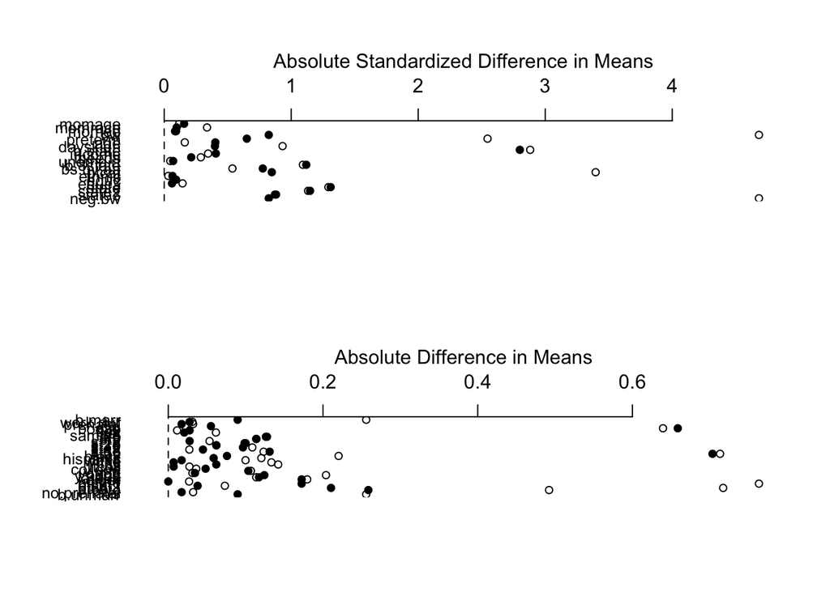

```
## $raw
##    b.unmarr no.prenatal         bwg      ptcat3      ptcat2      ptcat1
##  0.25583914  0.03211676  0.49225634  0.71727510  0.07313615  0.76352296
##      ptcat0       older      late20     y.adult       young       v.yng
##  0.02688829  0.17957164  0.11365993  0.20387478  0.03120643  0.10675663
##     college      ltcoll          hs        lths       white    hispanic
##  0.03608763  0.02734514  0.14207638  0.13333390  0.09985165  0.12029181
##       black        st99        st53        st48        st42        st36
##  0.22014346  0.71327304  0.12326469  0.02726169  0.10865061  0.06224260
##        st25        st12         st9         st5      sample       first
##  0.09863788  0.05331215  0.11370544  0.12619796          NA  0.06159020
##         sex       booze         cig    prenatal    work.dur      b.marr
##  0.01141867  0.63948954  0.02173147  0.03211676  0.03121992  0.25583914
##
## $matched
##    b.unmarr no.prenatal         bwg      ptcat3      ptcat2      ptcat1
## 0.089655172 0.017241379 0.258620690 0.210344828 0.037931034 0.172413793
##      ptcat0       older      late20     y.adult       young       v.yng
## 0.000000000 0.172413793 0.117241379 0.124137931 0.034482759 0.103448276
##     college      ltcoll          hs        lths       white    hispanic
## 0.048275862 0.006896552 0.062068966 0.006896552 0.017241379 0.058620690
##       black        st99        st53        st48        st42        st36
## 0.075862069 0.703448276 0.131034483 0.044827586 0.096551724 0.062068966
##        st25        st12         st9         st5      sample       first
## 0.100000000 0.027586207 0.113793103 0.127586207          NA 0.020689655
##         sex       booze         cig    prenatal    work.dur      b.marr
## 0.027586207 0.658620690 0.055172414 0.017241379 0.027586207 0.089655172
```

```r
plot.balance(bal_20.9, which.covs = "binary")
```

Doesn’t match up exactly, also this function doesn’t fix the issues with binary covariates

# Figure 20.10

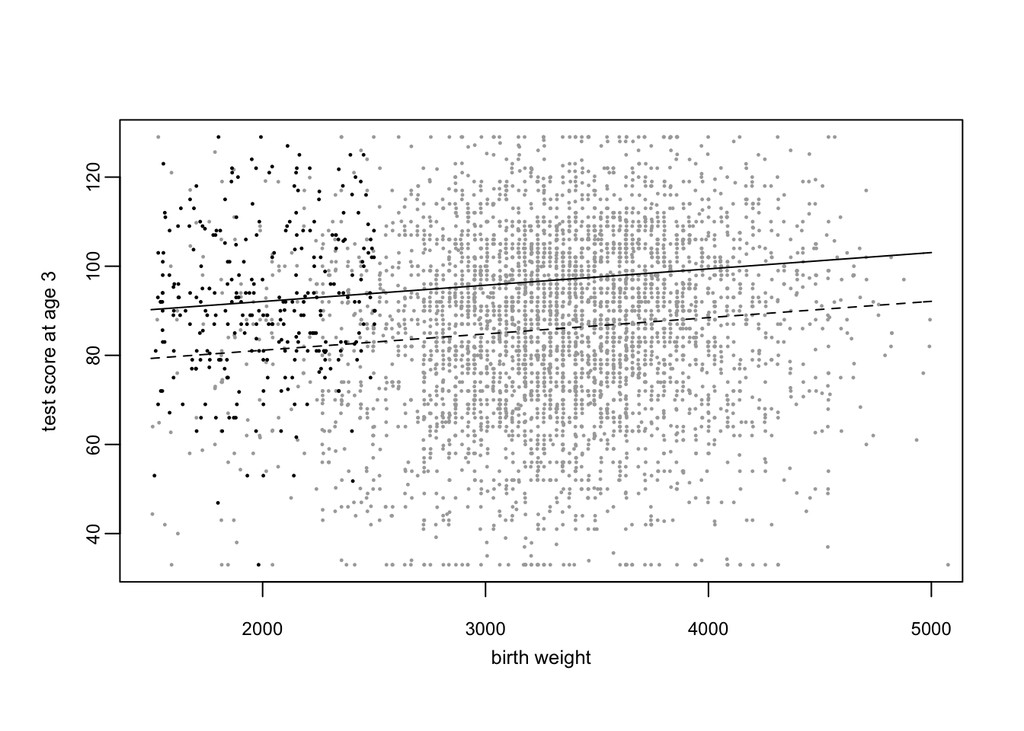

```r
# birthweight postscript('ppvt.bw.ps', horizontal=T,height=3.6,width=4.2)
par(mfrow = c(1, 1))
tmp <- lm(ppvtr.36 ~ bw + treat, data = cc2)$coef
plot(cc2$bw, cc2$ppvtr.36, xlab = "birth weight", ylab = "test score at age 3", mgp = c(2,
    0.5, 0), main = "", type = "n", xlim = c(1500, 5000), cex.axis = 0.75, cex.lab = 0.8,
    lab = c(3, 5, 7), xaxt = "n")
axis(side = 1, at = c(2000, 3000, 4000, 5000), cex.axis = 0.75)
points(cc2$bw[cc2$treat == 0] + runif(sum(cc2$treat == 0), -0.5, 5), cc2$ppvtr.36[cc2$treat ==
    0], col = "darkgrey", pch = 20, cex = 0.3)
points(cc2$bw[cc2$treat == 1] + runif(sum(cc2$treat == 1), -0.5, 5), cc2$ppvtr.36[cc2$treat ==
    1], pch = 20, cex = 0.3)
curve(tmp[1] + tmp[2] * x, add = T, lty = 2)
curve(tmp[1] + tmp[3] + tmp[2] * x, add = T)
```

```r
# dev.off()
```

# Figure 20.11

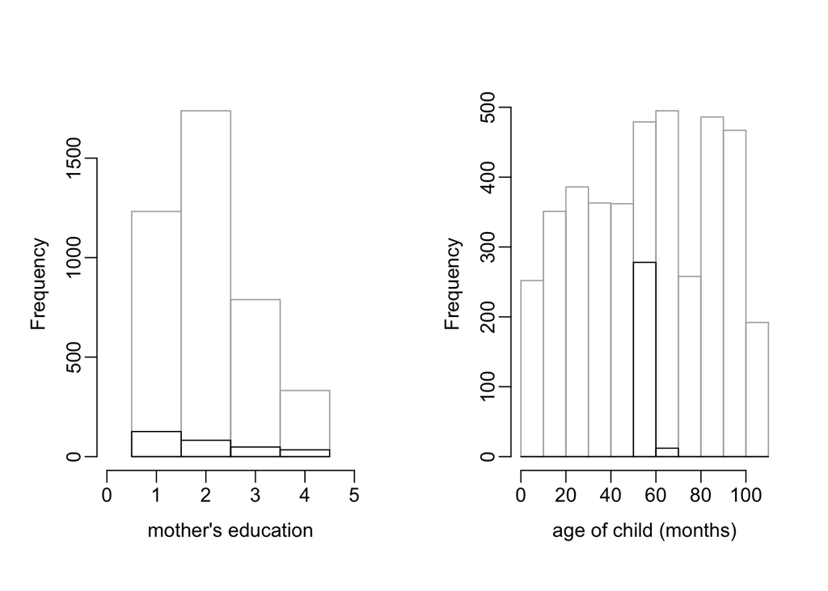

```r
par(mfrow = c(1, 2))
# plot(x=seq(0,5,.1),y=seq(0,1800,(1800/50)),bty='n',xaxt='n',yaxt='n',mgp=c(2,.5,0),xlab='mother's
# education',ylab='frequency',type='n',main='') axis(1, 1:4) axis(2,
# c(0,1000,2000))
hist(cc2$educ[cc2$treat == 0], xlim = c(0, 5), main = "", border = "darkgrey", breaks = c(0.5,
    1.5, 2.5, 3.5, 4.5), mgp = c(2, 0.5, 0), xlab = "mother's education", freq = TRUE)
hist(cc2$educ[cc2$treat == 1], xlim = c(0, 5), xlab = "education", breaks = c(0.5,
    1.5, 2.5, 3.5, 4.5), freq = TRUE, add = T)
#
hist(cc2$age[cc2$treat == 0], xlim = c(0, 110), main = "", xlab = "age of child (months)",
    border = "darkgrey", breaks = seq(0, 110, 10), mgp = c(2, 0.5, 0), freq = TRUE)
hist(cc2$age[cc2$treat == 1], xlim = c(0, 110), xlab = "", breaks = seq(0, 110, 10),
    freq = TRUE, add = T)
```

# Figure 20.12

## Original code

```r
# Stratified analyses CODE THIS MORE EFFICIENTLY!  use aggregate function?  or
# just one of the apply's?
tes.ns <- matrix(0, 4, 4)
tes.ns[1, ] <- c(mean(cc2$ppvtr.36[cc2$treat == 1 & cc2$lths == 1]) - mean(cc2$ppvtr.36[cc2$treat ==
    0 & cc2$lths == 1]), sum(cc2$treat == 1 & cc2$lths == 1), sum(cc2$lths == 1),
    sqrt(var(cc2$ppvtr.36[cc2$treat == 1 & cc2$lths == 1])/sum(cc2$treat == 1 & cc2$lths ==
        1) + var(cc2$ppvtr.36[cc2$treat == 0 & cc2$lths == 1])/sum(cc2$treat == 0 &
        cc2$lths == 1)))
tes.ns[2, ] <- c(mean(cc2$ppvtr.36[cc2$treat == 1 & cc2$hs == 1]) - mean(cc2$ppvtr.36[cc2$treat ==
    0 & cc2$hs == 1]), sum(cc2$treat == 1 & cc2$hs == 1), sum(cc2$hs == 1), sqrt(var(cc2$ppvtr.36[cc2$treat ==
    1 & cc2$hs == 1])/sum(cc2$treat == 1 & cc2$hs == 1) + var(cc2$ppvtr.36[cc2$treat ==
    0 & cc2$hs == 1])/sum(cc2$treat == 0 & cc2$hs == 1)))
tes.ns[3, ] <- c(mean(cc2$ppvtr.36[cc2$treat == 1 & cc2$ltcoll == 1]) - mean(cc2$ppvtr.36[cc2$treat ==
    0 & cc2$ltcoll == 1]), sum(cc2$treat == 1 & cc2$ltcoll == 1), sum(cc2$ltcoll ==
    1), sqrt(var(cc2$ppvtr.36[cc2$treat == 1 & cc2$ltcoll == 1])/sum(cc2$treat ==
    1 & cc2$ltcoll == 1) + var(cc2$ppvtr.36[cc2$treat == 0 & cc2$ltcoll == 1])/sum(cc2$treat ==
    0 & cc2$ltcoll == 1)))
tes.ns[4, ] <- c(mean(cc2$ppvtr.36[cc2$treat == 1 & cc2$college == 1]) - mean(cc2$ppvtr.36[cc2$treat ==
    0 & cc2$college == 1]), sum(cc2$treat == 1 & cc2$college == 1), sum(cc2$college ==
    1), sqrt(var(cc2$ppvtr.36[cc2$treat == 1 & cc2$college == 1])/sum(cc2$treat ==
    1 & cc2$college == 1) + var(cc2$ppvtr.36[cc2$treat == 0 & cc2$college == 1])/sum(cc2$treat ==
    0 & cc2$college == 1)))

rownames(tes.ns) <- c("lths", "hs", "ltcoll", "college")
colnames(tes.ns) <- c("te", "n.trt", "n.ctrl", "se")
round(tes.ns, 2)
```

```
##           te n.trt n.ctrl   se
## lths    9.30   126   1358 1.46
## hs      4.06    82   1820 1.87
## ltcoll  7.87    48    837 2.40
## college 4.62    34    366 2.32
```

## New code

Apply function implementation. Also, in original code the sample size for controls is controls plus treatment. Though these samples sizes are what are reported in both the original and new texts!

```r
edu <- list(cc2$lths, cc2$hs, cc2$ltcoll, cc2$college)

# mean difference
y.trt <- sapply(edu, FUN = function(x) {
    tapply(cc2$ppvtr.36, list(cc2$treat, x), mean)[4]
})
y.ctrl <- sapply(edu, FUN = function(x) {
    tapply(cc2$ppvtr.36, list(cc2$treat, x), mean)[3]
})
te <- y.trt - y.ctrl

# sample sizes
n.trt <- sapply(edu, FUN = function(x) {
    tapply(rep(1, nrow(cc2)), list(cc2$treat, x), sum)[4]
})
n.ctrl <- sapply(edu, FUN = function(x) {
    sum(tapply(rep(1, nrow(cc2)), list(cc2$treat, x), sum)[3])
})

# std errors
var.trt <- sapply(edu, FUN = function(x) {
    tapply(cc2$ppvtr.36, list(cc2$treat, x), var)[4]
})
var.ctrl <- sapply(edu, FUN = function(x) {
    tapply(cc2$ppvtr.36, list(cc2$treat, x), var)[3]
})
se <- sqrt(var.trt/n.trt + var.ctrl/n.ctrl)

tes <- matrix(c(te, n.trt, n.ctrl, se), nrow = 4)
rownames(tes) <- c("lths", "hs", "ltcoll", "college")
colnames(tes.ns) <- c("te", "n.trt", "n.ctrl", "se")

round(tes, 2)
```

```
##         [,1] [,2] [,3] [,4]
## lths    9.30  126 1232 1.46
## hs      4.06   82 1738 1.87
## ltcoll  7.87   48  789 2.40
## college 4.62   34  332 2.32
```

Also order of columns should be te+se, then sample sizes to match text.

# Propensity score fitting

```r
covs.bin.nr <- c("bwg", "hispanic", "black", "b.marr", "lths", "hs", "ltcoll", "work.dur",
    "prenatal", "sex", "first", "st5", "st9", "st12", "st25", "st36", "st42", "st48",
    "st53")
covs.cont <- c("bw", "preterm", "momage", "dayskidh")
covs.nr <- c(covs.cont, covs.bin.nr)
form.nr <- as.formula(cc2[, c("treat", covs.nr)])
print(form.nr)
```

```
## treat ~ bw + preterm + momage + dayskidh + bwg + hispanic + black +
##     b.marr + lths + hs + ltcoll + work.dur + prenatal + sex +
##     first + st5 + st9 + st12 + st25 + st36 + st42 + st48 + st53
## <environment: 0x7f8ef8390e40>
```

```r
ps_fit <- stan_glm(form.nr, family = binomial(link = "logit"), data = cc2, algorithm = "optimizing")

pscores <- posterior_linpred(ps_fit, type = "link")
pscores.mean <- apply(pscores, 2, mean)

matches <- matching(z = cc2$treat, score = pscores.mean, replace = FALSE)
matched <- cc2[matches$match.ind, ]

matches.wr <- matching(z = cc2$treat, score = pscores.mean, replace = TRUE)
wts.wr <- matches.wr$cnts
```

Text doesn’t use mean of p-scores in matching function, typo?

# Figure 20.13

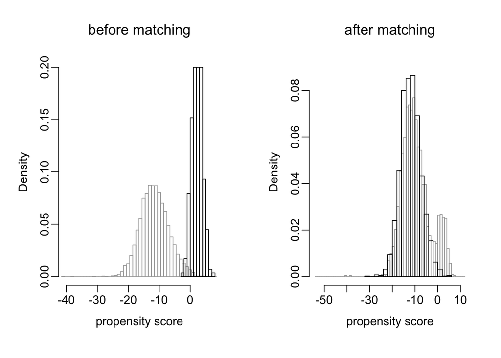

```r
xmin <- range(pscores.mean)[1]
xmax <- range(pscores.mean)[2]
par(mfrow = c(1, 2))
hist(pscores.mean[cc2$treat == 0], xlim = c(xmin, xmax), ylim = c(0, 0.2), main = "before matching",
    border = "darkgrey", breaks = seq(xmin - 1, xmax + 1, by = 1), mgp = c(2, 0.5,
        0), xlab = "propensity score", freq = FALSE)
hist(pscores.mean[cc2$treat == 1], freq = FALSE, add = TRUE)
hist(pscores.mean[matched$treat == 0], xlim = c(-54, 12), ylim = c(0, 0.09), main = "after matching",
    border = "darkgrey", breaks = seq(-54, 12, by = 1), mgp = c(2, 0.5, 0), xlab = "propensity score",
    freq = FALSE)
hist(pscores.mean[matched$treat == 1], freq = FALSE, add = TRUE)
```

```r
dev.off()
```

Check if p-scores of treated units greater than max of p-scores of control units.

```r
sum(pscores[cc2$treat == 1] > max(pscores[cc2$treat == 0]))
```

```
## [1] 0
```

# Figure 20.14

Big table of data stratified by covariates, treatment, potential outcomes, p-score, weight.